# Analiza składu jeziora

### 13.3 Eksploracja zmiennych przyczynowych- SEM

```r
model_sem <- 'ITS ~ chla + temp + nas
              temp ~ nas'
fit <- sem(model_sem, data = dane)
summary(fit)
```

```
lavaan 0.6-19 ended normally after 2 iterations

  Estimator                                         ML
  Optimization method                           NLMINB
  Number of model parameters                         6

  Number of observations                            51

Model Test User Model:

  Test statistic                                 0.034
  Degrees of freedom                                 1
  P-value (Chi-square)                           0.854

Parameter Estimates:

  Standard errors                             Standard
  Information                                 Expected
  Information saturated (h1) model          Structured

Regressions:
                   Estimate  Std.Err  z-value  P(>|z|)
  ITS ~
    chla              0.003    0.002    1.331    0.183
    temp              0.022    0.011    1.981    0.048
    nas               0.012    0.003    4.172    0.000
  temp ~
    nas               0.045    0.031    1.471    0.141

Variances:
                   Estimate  Std.Err  z-value  P(>|z|)
   .ITS               0.067    0.013    5.050    0.000
   .temp             10.788    2.136    5.050    0.000
```

- Statystyki dopasowania sugerują, że model dobrze pasuje do danych (wysokie p-value dla testu chi-kwadrat, brak dowodów na niedopasowanie)
- **nas:** silny i istotny wpływ na ITS (p < 0.001), co sugeruje, że jest to kluczowa zmienna wyjaśniająca
- **chla:** Nieistotny wpływ na ITS (p = 0.183), może być mniej ważna w kontekście tego modelu

### 13.4 Wykres ścieżek

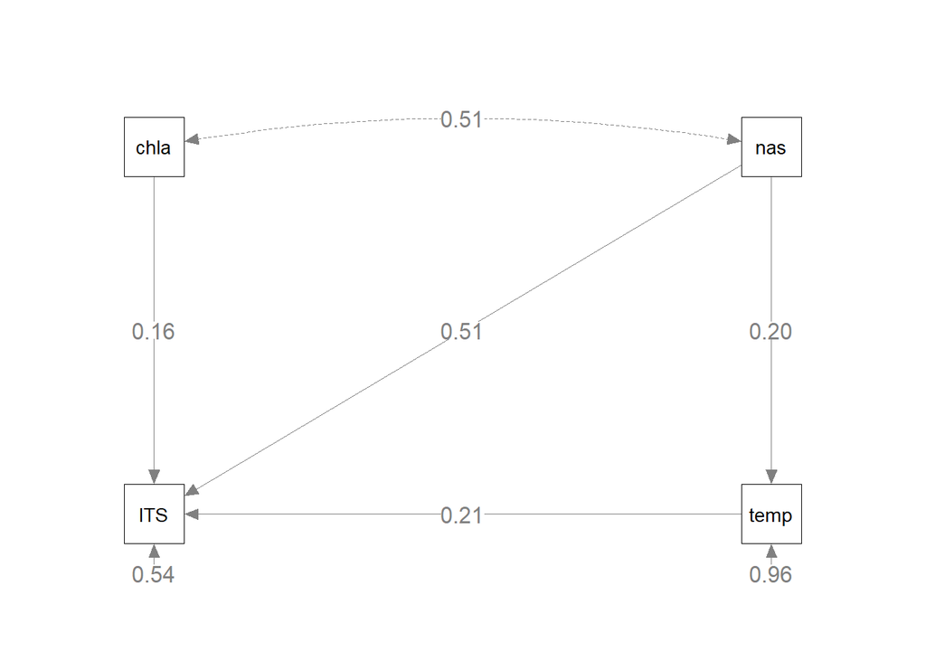

```r
# Tworzenie wykresu ścieżek
semPlot::semPaths(fit,
                 whatLabels = "std", # Wyświetlanie standardowych współczynników
                 style = "lisrel",
                 layout = "tree",
                 edge.label.cex = 1.2,
                 nCharNodes = 0,
                 sizeMan = 7,
                 sizeLat = 9,
                 title = FALSE)
```

- Zmienna nas ma największy wpływ na ITS (współczynnik 0.51), co potwierdza wcześniejsze analizy.
- Zmienna temp ma umiarkowany wpływ na ITS (0.21), ale także jest zależne od nas (0.20), co wskazuje na złożone zależności.
- Zmienna nas wpływa na ITS zarówno bezpośrednio (0.51), jak i pośrednio przez temp.